# Introduction to the Transition-class

Max Gordon

2016-03-23

# Introduction

The *Transition*-class is the advanced version of transitionPlot that aims at illustrating the transition between classes over time. The original intent was to show how [self-administered the Charnley classification](http://informahealthcare.com/doi/full/10.3109/17453674.2014.931199) behaves before and after surgery. The plot is a fancier version than what can be achiewed using packages such as [*diagram*](http://informahealthcare.com.proxy.kib.ki.se/doi/full/10.3109/17453674.2014.931199) but at the cost of flexibility. The current function only allows to show transitions from one state to the next and there is generally no going back.

# Generate some data

We will start by simulating some data similar to my article. Each observation has a sex and a Charnley class (A, B, or C). The transition is then dependent on both the sex and the Charnley class.

```r
set.seed(1)
library(magrittr)
n <- 100
data <-
  data.frame(
    Sex = sample(c("Male", "Female"),
                 size = n,
                 replace = TRUE,
                 prob = c(.4, .6)),
    Charnley_class = sample(c("A", "B", "C"),
                            size = n,
                            replace = TRUE))
getProbs <- function(Chrnl_name){
  prob <- data.frame(
    A = 1/3 +
      (data$Sex == "Male") * .25 +
      (data$Sex != "Male") * -.25 +
      (data[[Chrnl_name]] %in% "B") * -.5 +
      (data[[Chrnl_name]] %in% "C") * -2 ,
    B = 1/3 +
      (data$Sex == "Male") * .1 +
      (data$Sex != "Male") * -.05 +
      (data[[Chrnl_name]] == "C") * -2,
    C = 1/3 +
      (data$Sex == "Male") * -.25 +
      (data$Sex != "Male") * .25)

  # Remove negative probabilities
  t(apply(prob, 1, function(x) {
    if (any(x < 0)){
      x <- x - min(x) + .05
      }
    x
    }))
}

Ch_classes <- c("Charnley_class")
Ch_classes %<>% c(sprintf("%s_%dyr", Ch_classes, c(1,2,6)))
for (i in 1:length(Ch_classes)){
  if (i == 1)
    next;

  data[[Ch_classes[i]]] <-
    apply(getProbs(Ch_classes[i-1]), 1, function(p)
      sample(c("A", "B", "C"),
             size = 1,
             prob = p)) %>%
    factor(levels = c("A", "B", "C"))
}
```

# Basic use

The most simple use is to just supply the output from the `table()` call:

```r
library(Gmisc)
transitions <- getRefClass("Transition")$new(table(data$Charnley_class, data$Charnley_class_1yr),
                                                  label=c("Before surgery", "1 year after"))
transitions$render()
```

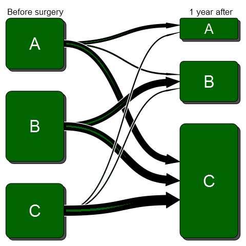

Adding customizations are rather straight forward by setting the different field arguments:

```r
transitions <- getRefClass("Transition")$new(table(data$Charnley_class, data$Charnley_class_1yr),
                                                  label=c("Before surgery", "1 year after"))
transitions$title <- "Charnley class in relation to THR"
transitions$arrow_type <- "simple"
transitions$box_label_pos <- "bottom"
transitions$render()
```

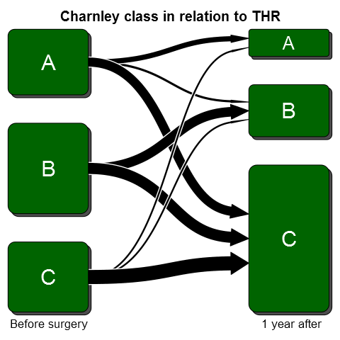

## Adding a third dimension

```r
transitions <- getRefClass("Transition")$new(table(data$Charnley_class, data$Charnley_class_1yr, data$Sex),
                                                  label=c("Before surgery", "1 year after"))
transitions$title <- "Charnley class in relation to THR"
transitions$clr_bar <- "top"
transitions$render()
```

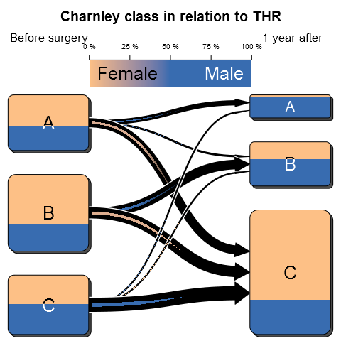

# Multiple transitions

The major advantage with the **Transition**-class is that it allows for transitions at multiple time points. We do this by calling the **addTransitions** function as shown below:

```r
transitions <- getRefClass("Transition")$new(table(data$Charnley_class, data$Charnley_class_1yr, data$Sex),
                                                  label=c("Before surgery", "1 year after"))
transitions$title <- "Charnley class in relation to THR"
transitions$addTransitions(table(data$Charnley_class_1yr, data$Charnley_class_2yr, data$Sex), label="2 years after")
library(grid)
transitions$max_lwd <- unit(.05, "npc")
transitions$render()
```

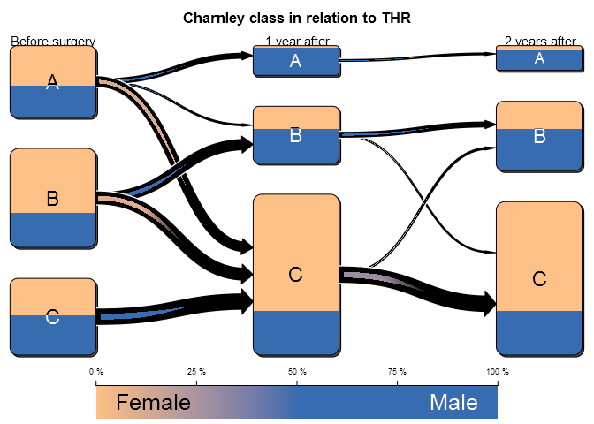